# Week 6 Project

Nancy Wangare

2025-07-02

## Load Libraries

```r
pacman::p_load(
  #data importation
  tidyverse, readxl,
  #Data Visualization
  ggplot2

)
```

## Load Dataset

```r
library(readxl)
df <- read_excel("week6_dataset.xlsx")
```

## **Core Questions for Week 6 (IQR & Boxplot**)

### **1. What are the IQR values for Income and Age?**

### i. Calculate Q1, Q3, and IQR.

```r
#Age
q1_age <- quantile(df$Age, 0.25)
q3_age <- quantile(df$Age, 0.75)
iqr_age <- IQR(df$Age)
cat("Q1 is ", q1_age, "\n ", "Q3 is ", q3_age, "\n", "IQR is ", iqr_age )
```

```
## Q1 is  28
##   Q3 is  42
##  IQR is  14
```

```r
#Income
q1_income <- quantile(df$Income, 0.25)
q3_income <- quantile(df$Income, 0.75)
iqr_income <- IQR(df$Income)
cat("Q1 is ", q1_income, "\n ","Q3 is ", q3_income, "\n","IQR is ", iqr_income )
```

```
## Q1 is  41704.5
##   Q3 is  58151
##  IQR is  16446.5
```

### ii. Determine lower and upper bounds for detecting outliers.

```r
#Lower  and upper bound of Age
lb_age <- q1_age - (1.5*iqr_age)
ub_age <- q3_age + (1.5*iqr_age)
cat("Lower bound of Age =", lb_age, "\n", "Upper bound of Age =", ub_age)
```

```
## Lower bound of Age = 7
##  Upper bound of Age = 63
```

```r
#Lower  and upper bound of Income
lb_income <- q1_income - (1.5*iqr_income)
ub_income <- q3_income + (1.5*iqr_income)
cat("Lower bound of Income =", lb_income, "\n", "Upper bound of Income =", ub_income)
```

```
## Lower bound of Income = 17034.75
##  Upper bound of Income = 82820.75
```

### **2. How many outliers exist in the dataset for Income and Age?**

### i. Count the number of rows outside the IQR bounds.

### ii. Separate the outliers for inspection.

```r
#Outliers for Age
outliers_age <- subset(df, Age < lb_age | Age > ub_age)
outliers_age
```

```
## # A tibble: 15 × 3
##       ID   Age Income
##    <dbl> <dbl>  <dbl>
##  1   196     3  52088
##  2   260    65  43027
##  3   732    71  30056
##  4   941     3  59967
##  5  1581     6  62947
##  6  1639    -3  29130
##  7  1658    64  46433
##  8  1695    -1  53644
##  9  2043     4  71731
## 10  2186     6  49923
## 11  2245     6  51965
## 12  3641    66  52039
## 13  4257     3  62169
## 14  4645     5  49300
## 15  4732    65  69307
```

```r
#Outliers for Income
outliers_income <- subset(df, Income < lb_income | Income > ub_income)
outliers_income
```

```
## # A tibble: 31 × 3
##       ID   Age Income
##    <dbl> <dbl>  <dbl>
##  1   293    45  16064
##  2   423    28  14467
##  3   848    37  15492
##  4  1337    43  83254
##  5  1387    35  85954
##  6  1703    27  85065
##  7  1742    30   5774
##  8  1754    16  15862
##  9  1857    39   7157
## 10  1988    37  83248
## # ℹ 21 more rows
```

### **3. What percentage of the dataset is made up of outliers (for each variable)?**

### i. Example: “Outliers in Income make up 3.4% of the data.”

```r
# Percentage for Age
percentage_age <- (nrow(outliers_age)/ nrow(df)) * 100
 percentage_age
```

```
## [1] 0.3
```

```r
# Percentage for Income
percentage_income <- (nrow(outliers_income)/ nrow(df)) * 100
 percentage_income
```

```
## [1] 0.62
```

### **4. What does the distribution of Income look like before and after removing outliers?**

### i. Visualize with boxplots.

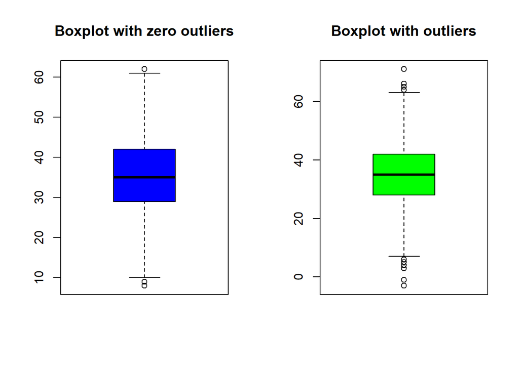

```r
#Dataframe without Outliers for Age
par(mfrow = c(1,2))
zeroOutlier_Age <- subset(df, Age > lb_age & Age < ub_age)
boxplot(zeroOutlier_Age$Age, main="Boxplot with zero outliers", col = "blue")
boxplot(df$Age, main= "Boxplot with outliers", col = "green")
```

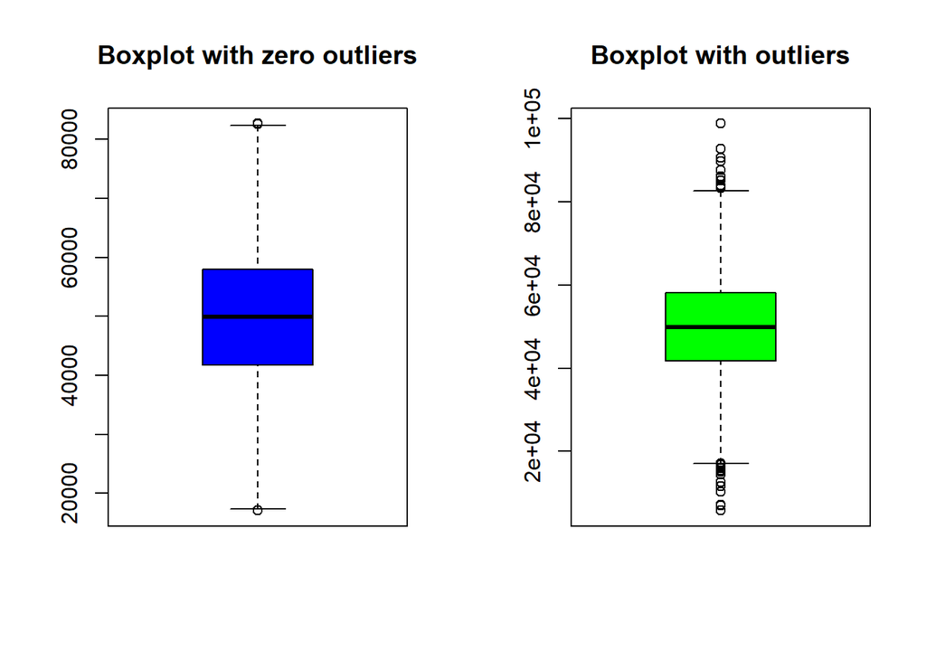

```r
#Dataframe without Outliers for Income
par(mfrow = c(1,2))
zeroOutlier_Income <- subset(df, Income > lb_income & Income < ub_income)
boxplot(zeroOutlier_Income$Income, main="Boxplot with zero outliers", col = "blue")
boxplot(df$Income, main= "Boxplot with outliers", col = "green")
```

### ii. Optionally add histograms or density plots for comparison.

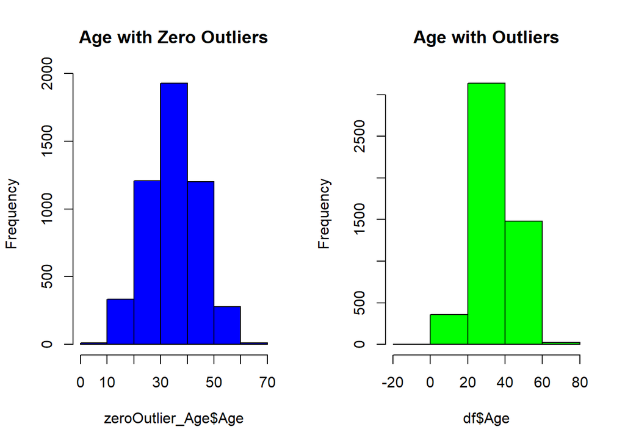

```r
par(mfrow = c(1,2))
hist(zeroOutlier_Age$Age, main = "Age with Zero Outliers", col = "blue", breaks = 5)
hist(df$Age, main = "Age with Outliers", col = "green", breaks = 5)
```

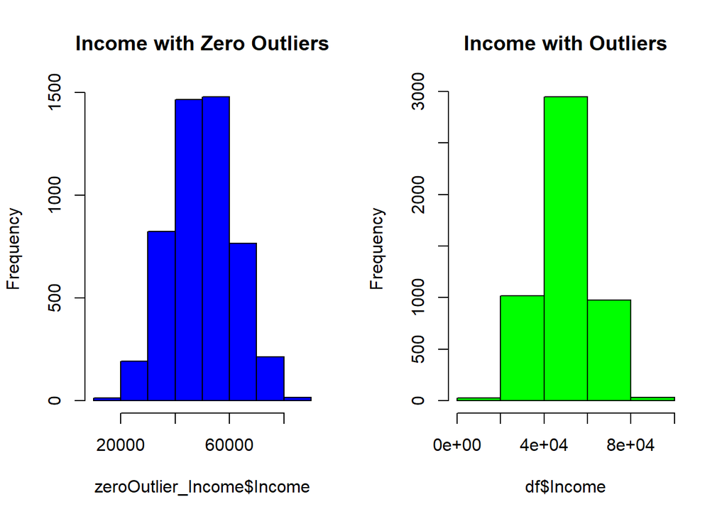

```r
par(mfrow = c(1,2))
hist(zeroOutlier_Income$Income, main = "Income with Zero Outliers", col = "blue", breaks = 5)
hist(df$Income, main = "Income with Outliers", col = "green", breaks = 5)
```

### **5. Does removing outliers change the mean and median of Income or Age?**

### i. Compare summary statistics before and after.

```r
#Summary statistics of Age with Outliers
summary(df$Age)
```

```
##    Min. 1st Qu.  Median    Mean 3rd Qu.    Max.
##   -3.00   28.00   35.00   35.21   42.00   71.00
```

```r
#Summary statistics of Age without Outliers
summary(zeroOutlier_Age$Age)
```

```
##    Min. 1st Qu.  Median    Mean 3rd Qu.    Max.
##    8.00   29.00   35.00   35.25   42.00   62.00
```

```r
#Summary statistics of Income with Outliers
summary(df$Income)
```

```
##    Min. 1st Qu.  Median    Mean 3rd Qu.    Max.
##    5774   41705   49932   49980   58151   98817
```

```r
#Summary statistics of Income without Outliers
summary(zeroOutlier_Income$Income)
```

```
##    Min. 1st Qu.  Median    Mean 3rd Qu.    Max.
##   17105   41736   49923   49944   58028   82677
```

### ii. Interpret any major shifts in center or spread.

### 📍 **1. Center (Measures of Central Tendency)**

| Measure | With Outliers | Without Outliers | Shift | Interpretation |
| --- | --- | --- | --- | --- |
| **Mean** | 35.21 | 35.25 | ⬆️ Slight increase | Very minor change — suggests that low outliers (like -3) slightly pulled the mean down. After removing them, the average increased slightly. |
| **Median** | 35.00 | 35.00 | No change | The median is unchanged — this shows that the center of the distribution is stable and not affected by outliers. |

➡️ **Conclusion:** There is **no major shift in center**. The **mean is slightly influenced** by outliers, but the **median remains the same**, confirming that **most values are centered around 35**.

### 📏 **2. Spread (Measures of Dispersion)**

| Measure | With Outliers | Without Outliers | Shift | Interpretation |
| --- | --- | --- | --- | --- |
| **Min.** | -3.00 | 8.00 | ⬆️ Significant increase | The negative outlier was removed. Now the data starts from a more realistic minimum value. |
| **Max.** | 71.00 | 62.00 | ⬇️ Decrease | Extreme high value was removed. Spread is tighter and more representative. |
| **Range** | 71 - (-3) = **74** | 62 - 8 = **54** | ⬇️ Range decreased by 20 | This indicates reduced variability in the data. |
| **1st Qu. / 3rd Qu.** | 28.00 / 42.00 | 29.00 / 42.00 | ⬆️ Q1 slightly higher | Very minimal change — quartiles are stable, so the spread within the middle 50% of data (IQR) hasn’t changed much. |

➡️ **Conclusion:** There **is a moderate shift in spread**, mostly in the **extreme ends** (min and max). After removing outliers:

- The **range** shrank from 74 to 54, reflecting **less variability**.
- The **interquartile range (IQR)** remained stable, suggesting that the **core distribution is consistent**.

### ✅ **Overall Interpretation:**

- **Center:** Remained stable — the typical value in the dataset is still around 35.
- **Spread:** Decreased — extreme low and high values were removed, making the dataset more **compact and reliable**.
- This means the cleaned data now better reflects the **true distribution** of values without being distorted by outliers.

### Income

Let’s interpret the **shift in center and spread** for this second set of summary statistics — likely from a variable such as **income, salary, or expenditure** — **before and after removing outliers**.

### 🔹 **Summary Table**

| Statistic | With Outliers | Without Outliers | Change |
| --- | --- | --- | --- |
| **Min.** | 5,774 | 17,105 | ⬆️ Significant increase |
| **1st Quartile (Q1)** | 41,705 | 41,736 | ⬆️ Slight increase |
| **Median** | 49,932 | 49,923 | ⬇️ Negligible decrease |
| **Mean** | 49,980 | 49,944 | ⬇️ Slight decrease |
| **3rd Quartile (Q3)** | 58,151 | 58,028 | ⬇️ Slight decrease |
| **Max.** | 98,817 | 82,677 | ⬇️ Significant decrease |

## 📌 Interpretation

### **1. Center (Mean and Median)**

- **Mean** dropped **slightly** from 49,980 to 49,944.
- **Median** remained **virtually the same**: 49,932 → 49,923.

✅ **Interpretation:** The **center of the distribution** is **stable**, which suggests that:

- The **outliers were not highly influential** on the center values.
- The data is fairly **symmetric** and **well-behaved** in the middle 50%.

### **2. Spread (Min, Max, Quartiles, Range)**

- **Min.** jumped from **5,774** to **17,105** → shows that very **low values were removed**.
- **Max.** dropped from **98,817** to **82,677** → indicates removal of **high-end outliers**.
- **Range:**
  - With outliers: 98,817 - 5,774 = **93,043**
  - Without outliers: 82,677 - 17,105 = **65,572** ⬇️ **Range reduced significantly**.
- **Quartiles (Q1 & Q3):** Barely changed → the **middle 50% of data (IQR)** remained stable.

✅ **Interpretation:**

- **Spread has reduced**, primarily at the **extremes** (minimum and maximum).
- **Quartiles are consistent**, suggesting most data points lie in a tight range and only **a few extreme values were removed**.
- The **reduced spread** means the cleaned dataset is now more **reliable and interpretable** without distortion from outliers.

### ✅ **Overall Interpretation**

- **Center** (mean and median) → **No major shift**
- **Spread** → **Significantly reduced**, especially by trimming extreme low and high values
- The data is now **more robust**, with a tighter range, and still preserves its central tendency.

### **6. Can we visually identify outliers using boxplots for Income and Age?**

### Generate:

### i. Boxplot for Income

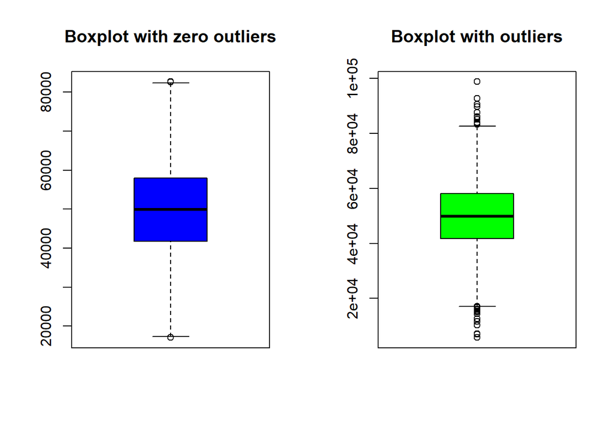

```r
#Dataframe without Outliers for Income
par(mfrow = c(1,2))
zeroOutlier_Income <- subset(df, Income > lb_income & Income < ub_income)
boxplot(zeroOutlier_Income$Income, main="Boxplot with zero outliers", col = "blue")
boxplot(df$Income, main= "Boxplot with outliers", col = "green")
```

### Optionally, facet or combine for before/after views.

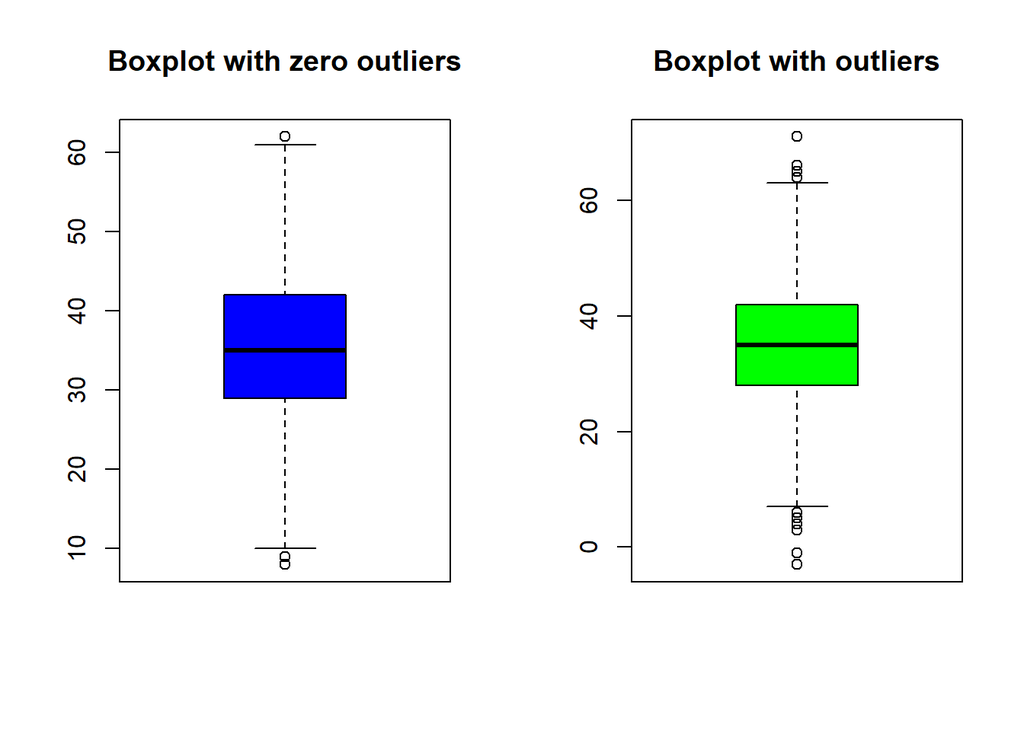

```r
#Dataframe without Outliers for Age
par(mfrow = c(1,2))
zeroOutlier_Age <- subset(df, Age > lb_age & Age < ub_age)
boxplot(zeroOutlier_Age$Age, main="Boxplot with zero outliers", col = "blue")
boxplot(df$Age, main= "Boxplot with outliers", col = "green")
```

### **🎯 Bonus / Deeper Questions (Optional)**

### **7. Which rows (IDs) are considered outliers in Income?**

### i. Return a table of outlier IDs and their values.

```r
cat("\nIncome Outlier IDs:\n")
```

```
##
## Income Outlier IDs:
```

```r
print(outliers_age[, c("ID", "Income")])
```

[output not shown]

```r
cat("\nAge Outlier IDs:\n")
```

```
##
## Age Outlier IDs:
```

```r
print(outliers_age[, c("ID", "Age")])
```

```
## # A tibble: 15 × 2
##       ID   Age
##    <dbl> <dbl>
##  1   196     3
##  2   260    65
##  3   732    71
##  4   941     3
##  5  1581     6
##  6  1639    -3
##  7  1658    64
##  8  1695    -1
##  9  2043     4
## 10  2186     6
## 11  2245     6
## 12  3641    66
## 13  4257     3
## 14  4645     5
## 15  4732    65
```

### **8. Is there any relationship between being an outlier in Income and Age?**

### i. Identify rows that are outliers in both.

```r
outliers_both <- merge(outliers_age, outliers_income, by = "ID")
cat("\nOutliers in both Income and Age:\n")
```

```
##
## Outliers in both Income and Age:
```

```r
print(outliers_both[, c("ID", "Age.x", "Income.y")])
```

```
## [1] ID       Age.x    Income.y
## <0 rows> (or 0-length row.names)
```

### ii. Use scatterplot or cross-tabulation to visualize.

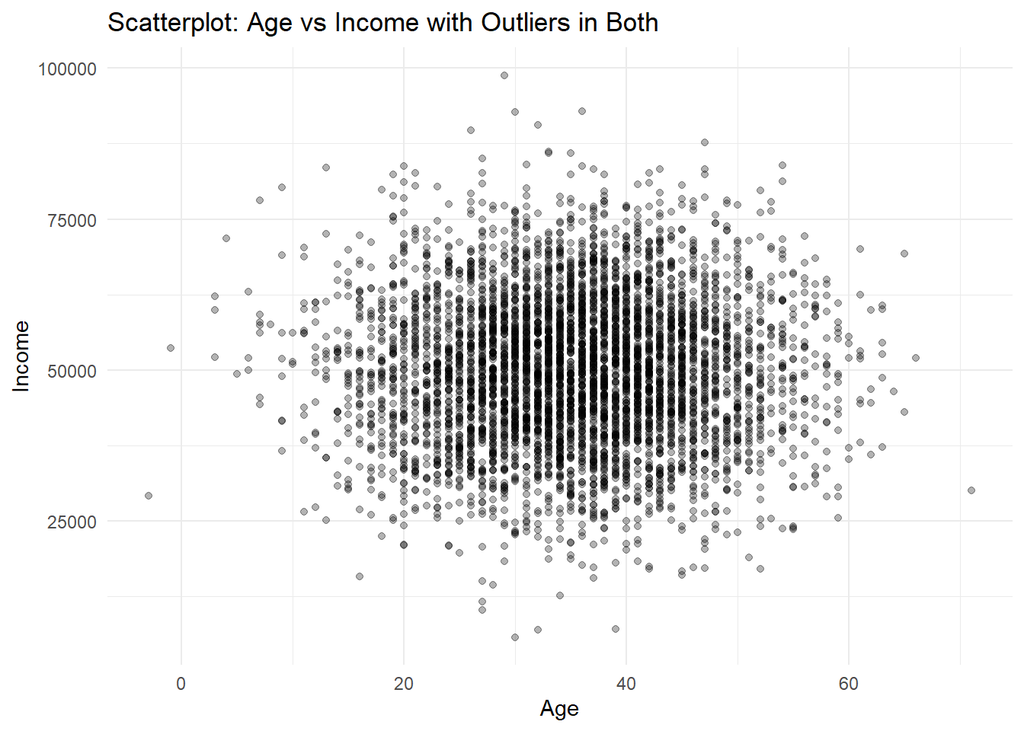

```r
# Scatterplot
ggplot(df, aes(x = Age, y = Income)) +
  geom_point(alpha = 0.3) +
  geom_point(data = outliers_both, aes(x = Age.x, y = Income.y), color = "blue") +
  ggtitle("Scatterplot: Age vs Income with Outliers in Both") +
  theme_minimal()
```

### **9. What’s the impact of outliers on standard deviation vs IQR?**

### i. Compute both measures before and after outlier removal.

```r
cat("\nStandard Deviation vs IQR:\n")
```

```
##
## Standard Deviation vs IQR:
```

```r
cat("Before:\n")
```

```
## Before:
```

```r
cat(sprintf("  Age STD: %.2f, IQR: %.2f\n", sd(df$Age), iqr_age))
```

```
##   Age STD: 9.89, IQR: 14.00
```

```r
cat(sprintf("  Income STD: %.2f, IQR: %.2f\n", sd(df$Income), iqr_income))
```

```
##   Income STD: 12099.93, IQR: 16446.50
```

```r
cat("After:\n")
```

```
## After:
```

```r
cat(sprintf("  Age STD: %.2f, IQR: %.2f\n", sd(zeroOutlier_Age$Age),
            IQR(zeroOutlier_Age$Age)))
```

```
##   Age STD: 9.65, IQR: 13.00
```

```r
cat(sprintf("  Income STD: %.2f, IQR: %.2f\n", sd(zeroOutlier_Income$Income),
            IQR(zeroOutlier_Income$Income)))
```

```
##   Income STD: 11774.57, IQR: 16292.00
```

### Impact of Outliers

#### 🔹 **Interquartile Range (IQR)**

- Decreased **slightly** in both cases.
- **Why?** IQR only uses the **middle 50%** of the data (between Q1 and Q3), so **outliers don’t affect it much**.
- The small drop suggests that the **core distribution stayed stable** while only a few outer points changed.

### **10. Are the outliers concentrated in any age group?**

### i. Group Age into bins (e.g., 20–30, 31–40) and count outliers in each bin.

```r
outliers_income$AgeGroup <- cut(outliers_income$Age,
                             breaks = c(10, 20, 30, 40, 50, 60, 70, 80),
                             include.lowest = TRUE, right = TRUE)

cat("\nIncome Outliers by Age Group:\n")
```

```
##
## Income Outliers by Age Group:
```

```r
print(table(outliers_income$AgeGroup))
```

```
##
## [10,20] (20,30] (30,40] (40,50] (50,60] (60,70] (70,80]
##       3       9      12       6       1       0       0
```